# 03. Mental Health Label 심층 분석

데이터셋의 핵심 도메인 컬럼인 `Mental_Health_Label`을 심층 분석합니다. 이 분석은 MindTune의 음악 심리 케어 기능의 근거가 됩니다.

**핵심 질문**:

- 각 Mental Health Label은 어떤 오디오 피처 프로파일을 가지는가?
- Depression, Anxiety, Bipolar 곡들은 피처 수준에서 유의미하게 구분되는가?
- 소수 라벨(PTSD 38곡, Depression 138곡)의 추천 다양성은 충분한가?
- 특정 라벨에 특정 장르가 편중되어 있는가?

```python
import pandas as pd
import numpy as np
import matplotlib.pyplot as plt
import seaborn as sns
from scipy import stats
import warnings

warnings.filterwarnings('ignore')
plt.rcParams['font.size'] = 11
plt.rcParams['figure.figsize'] = (12, 6)
plt.rcParams['axes.unicode_minus'] = False
sns.set_style('whitegrid')

df = pd.read_csv('../data/Music_recommendation.csv')

AUDIO_FEATURES = ['danceability', 'energy', 'valence', 'tempo',
                  'acousticness', 'instrumentalness', 'speechiness',
                  'loudness', 'liveness']

print("=== Mental Health Label 분포 ===")
mh_counts = df['Mental_Health_Label'].value_counts()
print(mh_counts)
print(f"\n고유 라벨 수: {df['Mental_Health_Label'].nunique()}")
```

```
=== Mental Health Label 분포 ===
Mental_Health_Label
Normal/Unclassified     22145
Bipolar (Mania)          5016
Anxiety                  4922
Bipolar (Depression)      335
Depression                138
Autism                    114
Schizophrenia             109
PTSD                       38
Dementia                    8
OCD                         8
Name: count, dtype: int64

고유 라벨 수: 10
```

## 3.1 라벨 분포 시각화

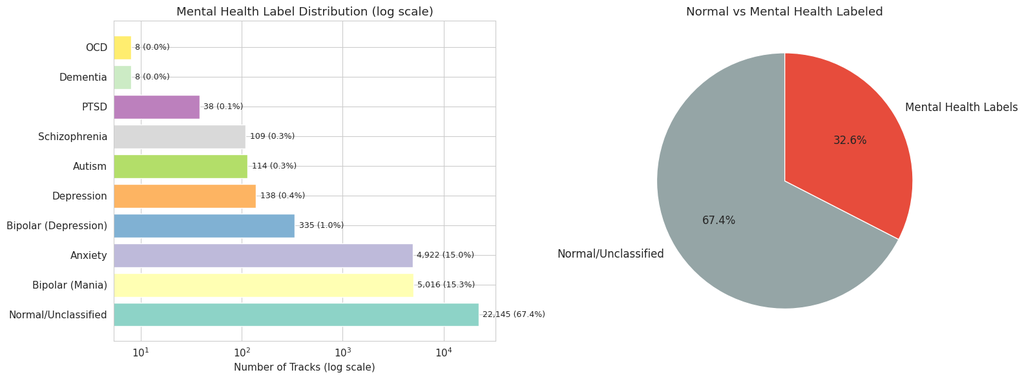

```
불균형 비율: Normal 대비 가장 적은 라벨 = 8곡 (1:2768)
```

```python
fig, axes = plt.subplots(1, 2, figsize=(16, 6))

# 막대 그래프 (로그 스케일)
colors_mh = plt.cm.Set3(np.linspace(0, 1, len(mh_counts)))
bars = axes[0].barh(mh_counts.index, mh_counts.values, color=colors_mh, edgecolor='white')
axes[0].set_xscale('log')
axes[0].set_xlabel('Number of Tracks (log scale)')
axes[0].set_title('Mental Health Label Distribution (log scale)')
for bar, val in zip(bars, mh_counts.values):
    axes[0].text(val * 1.1, bar.get_y() + bar.get_height()/2,
                f'{val:,} ({val/len(df)*100:.1f}%)', va='center', fontsize=9)

# 파이 차트 (Normal vs Non-Normal)
normal_count = mh_counts.get('Normal/Unclassified', 0)
non_normal_count = len(df) - normal_count
axes[1].pie([normal_count, non_normal_count],
            labels=['Normal/Unclassified', 'Mental Health Labels'],
            colors=['#95a5a6', '#e74c3c'], autopct='%1.1f%%', startangle=90,
            textprops={'fontsize': 12})
axes[1].set_title('Normal vs Mental Health Labeled')

plt.tight_layout()
plt.show()

print(f"\n불균형 비율: Normal 대비 가장 적은 라벨 = {mh_counts.min()}곡 "
      f"(1:{normal_count // mh_counts.min()})")
```

## 3.2 라벨별 오디오 피처 프로파일

각 Mental Health Label의 평균 오디오 피처를 비교합니다.

```python
# 라벨별 피처 평균값 테이블
profile = df.groupby('Mental_Health_Label')[AUDIO_FEATURES].mean().round(3)
profile['count'] = df.groupby('Mental_Health_Label').size()
profile = profile.sort_values('count', ascending=False)
print("=== 라벨별 오디오 피처 평균 프로파일 ===")
profile
```

```
=== 라벨별 오디오 피처 평균 프로파일 ===
```

| Mental_Health_Label | danceability | energy | valence | tempo | acousticness | instrumentalness | speechiness | loudness | liveness | count |
| --- | --- | --- | --- | --- | --- | --- | --- | --- | --- | --- |
| Normal/Unclassified | 0.662 | 0.655 | 0.507 | 117.350 | 0.195 | 0.059 | 0.113 | -7.109 | 0.183 | 22145 |
| Bipolar (Mania) | 0.704 | 0.826 | 0.820 | 122.322 | 0.141 | 0.054 | 0.101 | -5.644 | 0.197 | 5016 |
| Anxiety | 0.589 | 0.819 | 0.247 | 136.592 | 0.066 | 0.189 | 0.093 | -5.274 | 0.215 | 4922 |
| Bipolar (Depression) | 0.528 | 0.214 | 0.170 | 118.854 | 0.702 | 0.160 | 0.063 | -13.497 | 0.150 | 335 |
| Depression | 0.475 | 0.269 | 0.165 | 72.940 | 0.618 | 0.216 | 0.074 | -12.228 | 0.148 | 138 |
| Autism | 0.645 | 0.594 | 0.398 | 99.283 | 0.302 | 0.879 | 0.067 | -9.342 | 0.188 | 114 |
| Schizophrenia | 0.602 | 0.494 | 0.507 | 163.611 | 0.388 | 0.859 | 0.114 | -11.121 | 0.172 | 109 |
| PTSD | 0.488 | 0.657 | 0.192 | 103.545 | 0.214 | 0.116 | 0.091 | -7.686 | 0.813 | 38 |
| Dementia | 0.618 | 0.237 | 0.467 | 66.152 | 0.798 | 0.418 | 0.099 | -12.149 | 0.123 | 8 |
| OCD | 0.644 | 0.668 | 0.463 | 100.625 | 0.225 | 0.007 | 0.119 | -6.101 | 0.132 | 8 |

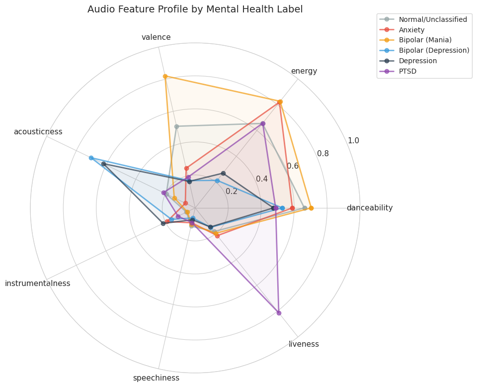

```python
# 레이더 차트: 주요 라벨의 피처 프로파일 비교
from matplotlib.patches import FancyBboxPatch

# 0~1 범위 피처만 사용 (레이더 차트에 적합)
radar_features = ['danceability', 'energy', 'valence', 'acousticness',
                  'instrumentalness', 'speechiness', 'liveness']
main_labels = ['Normal/Unclassified', 'Anxiety', 'Bipolar (Mania)',
               'Bipolar (Depression)', 'Depression', 'PTSD']
# 데이터에 존재하는 라벨만 필터
main_labels = [l for l in main_labels if l in df['Mental_Health_Label'].unique()]

angles = np.linspace(0, 2 * np.pi, len(radar_features), endpoint=False).tolist()
angles += angles[:1]  # 닫기

fig, ax = plt.subplots(figsize=(10, 10), subplot_kw=dict(polar=True))
label_colors = ['#95a5a6', '#e74c3c', '#f39c12', '#3498db', '#2c3e50', '#8e44ad']

for idx, label in enumerate(main_labels):
    values = df[df['Mental_Health_Label'] == label][radar_features].mean().tolist()
    values += values[:1]
    ax.plot(angles, values, 'o-', linewidth=2, label=label, color=label_colors[idx], alpha=0.7)
    ax.fill(angles, values, alpha=0.05, color=label_colors[idx])

ax.set_thetagrids(np.degrees(angles[:-1]), radar_features, fontsize=11)
ax.set_title('Audio Feature Profile by Mental Health Label', fontsize=14, y=1.08)
ax.legend(loc='upper right', bbox_to_anchor=(1.35, 1.1), fontsize=10)
ax.set_ylim(0, 1)
plt.tight_layout()
plt.show()
```

## 3.3 라벨별 주요 피처 분포 비교 (바이올린 플롯)

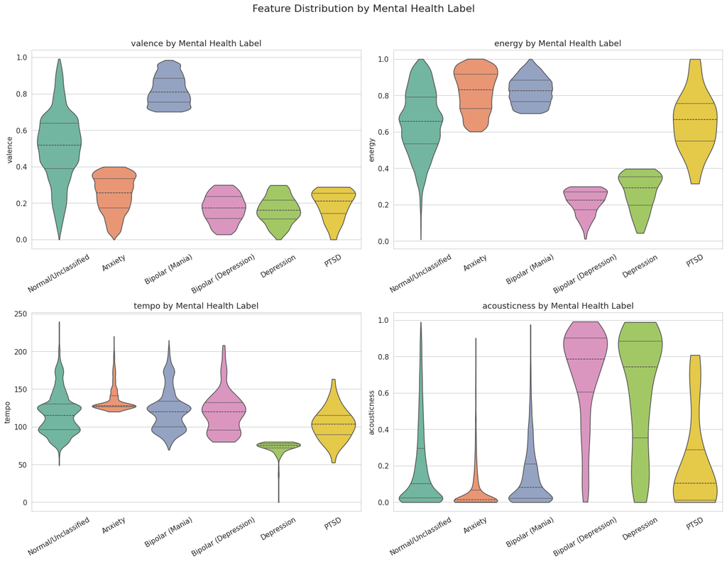

```python
key_features = ['valence', 'energy', 'tempo', 'acousticness']
fig, axes = plt.subplots(2, 2, figsize=(16, 12))

for idx, feat in enumerate(key_features):
    ax = axes[idx // 2, idx % 2]
    # 주요 라벨만 필터 (곡 수가 너무 적은 라벨은 시각화에 부적합)
    plot_df = df[df['Mental_Health_Label'].isin(main_labels)]
    sns.violinplot(data=plot_df, x='Mental_Health_Label', y=feat, ax=ax,
                   order=main_labels, palette='Set2', inner='quartile', cut=0)
    ax.set_title(f'{feat} by Mental Health Label', fontsize=13)
    ax.set_xlabel('')
    ax.tick_params(axis='x', rotation=30)

plt.suptitle('Feature Distribution by Mental Health Label', fontsize=16, y=1.02)
plt.tight_layout()
plt.show()
```

## 3.4 통계적 검정: Normal vs 각 라벨

Mann-Whitney U 검정으로 Normal/Unclassified 대비 각 라벨의 피처 차이가 통계적으로 유의한지 확인합니다.

```python
normal_df = df[df['Mental_Health_Label'] == 'Normal/Unclassified']
test_labels = [l for l in main_labels if l != 'Normal/Unclassified']
test_features = ['valence', 'energy', 'acousticness', 'danceability', 'tempo']

results = []
for label in test_labels:
    label_df = df[df['Mental_Health_Label'] == label]
    for feat in test_features:
        stat, p_value = stats.mannwhitneyu(normal_df[feat].dropna(), label_df[feat].dropna(), alternative='two-sided')
        # 효과 크기 (Cohen's d 근사)
        d = (label_df[feat].mean() - normal_df[feat].mean()) / normal_df[feat].std()
        results.append({
            'Label': label,
            'Feature': feat,
            'Normal_mean': normal_df[feat].mean(),
            'Label_mean': label_df[feat].mean(),
            'Diff': label_df[feat].mean() - normal_df[feat].mean(),
            'Cohen_d': d,
            'p_value': p_value,
            'Significant': '***' if p_value < 0.001 else ('**' if p_value < 0.01 else ('*' if p_value < 0.05 else 'ns'))
        })

results_df = pd.DataFrame(results)
print("=== Mann-Whitney U Test: Normal vs Each Label ===")
print("(*** p<0.001, ** p<0.01, * p<0.05, ns: not significant)")
print()
results_df[['Label', 'Feature', 'Normal_mean', 'Label_mean', 'Diff', 'Cohen_d', 'Significant']].round(3)
```

```
=== Mann-Whitney U Test: Normal vs Each Label ===
(*** p<0.001, ** p<0.01, * p<0.05, ns: not significant)
```

|  | Label | Feature | Normal_mean | Label_mean | Diff | Cohen_d | Significant |
| --- | --- | --- | --- | --- | --- | --- | --- |
| 0 | Anxiety | valence | 0.507 | 0.247 | -0.261 | -1.369 | *** |
| 1 | Anxiety | energy | 0.655 | 0.819 | 0.165 | 0.951 | *** |
| 2 | Anxiety | acousticness | 0.195 | 0.066 | -0.128 | -0.570 | *** |
| 3 | Anxiety | danceability | 0.662 | 0.589 | -0.073 | -0.501 | *** |
| 4 | Anxiety | tempo | 117.350 | 136.592 | 19.243 | 0.710 | *** |
| 5 | Bipolar (Mania) | valence | 0.507 | 0.820 | 0.313 | 1.643 | *** |
| 6 | Bipolar (Mania) | energy | 0.655 | 0.826 | 0.172 | 0.992 | *** |
| 7 | Bipolar (Mania) | acousticness | 0.195 | 0.141 | -0.054 | -0.238 | *** |
| 8 | Bipolar (Mania) | danceability | 0.662 | 0.704 | 0.042 | 0.290 | *** |
| 9 | Bipolar (Mania) | tempo | 117.350 | 122.322 | 4.972 | 0.183 | *** |
| 10 | Bipolar (Depression) | valence | 0.507 | 0.170 | -0.337 | -1.772 | *** |
| 11 | Bipolar (Depression) | energy | 0.655 | 0.214 | -0.441 | -2.550 | *** |
| 12 | Bipolar (Depression) | acousticness | 0.195 | 0.702 | 0.507 | 2.254 | *** |
| 13 | Bipolar (Depression) | danceability | 0.662 | 0.528 | -0.134 | -0.927 | *** |
| 14 | Bipolar (Depression) | tempo | 117.350 | 118.854 | 1.505 | 0.055 | ns |
| 15 | Depression | valence | 0.507 | 0.165 | -0.343 | -1.800 | *** |
| 16 | Depression | energy | 0.655 | 0.269 | -0.386 | -2.229 | *** |
| 17 | Depression | acousticness | 0.195 | 0.618 | 0.423 | 1.882 | *** |
| 18 | Depression | danceability | 0.662 | 0.475 | -0.187 | -1.293 | *** |
| 19 | Depression | tempo | 117.350 | 72.940 | -44.410 | -1.638 | *** |
| 20 | PTSD | valence | 0.507 | 0.192 | -0.315 | -1.656 | *** |
| 21 | PTSD | energy | 0.655 | 0.657 | 0.002 | 0.011 | ns |
| 22 | PTSD | acousticness | 0.195 | 0.214 | 0.019 | 0.085 | ns |
| 23 | PTSD | danceability | 0.662 | 0.488 | -0.174 | -1.202 | *** |
| 24 | PTSD | tempo | 117.350 | 103.545 | -13.805 | -0.509 | ** |

## 3.5 Depression vs Anxiety vs Bipolar 비교

음악 추천 시 이 세 라벨의 차별화가 핵심입니다.

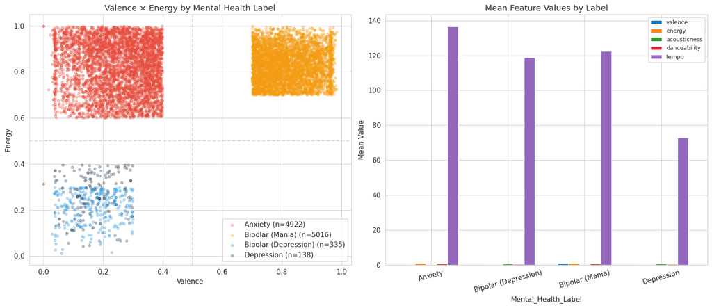

```python
# Valence × Energy 공간에서 주요 라벨 비교
compare_labels = ['Anxiety', 'Bipolar (Mania)', 'Bipolar (Depression)', 'Depression']
compare_labels = [l for l in compare_labels if l in df['Mental_Health_Label'].unique()]
label_colors_map = {'Anxiety': '#e74c3c', 'Bipolar (Mania)': '#f39c12',
                    'Bipolar (Depression)': '#3498db', 'Depression': '#2c3e50'}

fig, axes = plt.subplots(1, 2, figsize=(16, 7))

# 산점도
for label in compare_labels:
    subset = df[df['Mental_Health_Label'] == label]
    axes[0].scatter(subset['valence'], subset['energy'], alpha=0.3, s=15,
                    label=f"{label} (n={len(subset)})", color=label_colors_map.get(label, 'gray'))
axes[0].set_xlabel('Valence')
axes[0].set_ylabel('Energy')
axes[0].set_title('Valence × Energy by Mental Health Label')
axes[0].legend()
axes[0].axhline(0.5, color='gray', linestyle='--', alpha=0.3)
axes[0].axvline(0.5, color='gray', linestyle='--', alpha=0.3)

# 평균값 비교 테이블 시각화
compare_profile = df[df['Mental_Health_Label'].isin(compare_labels)].groupby('Mental_Health_Label')[test_features].mean()
compare_profile.plot(kind='bar', ax=axes[1], rot=15, width=0.7)
axes[1].set_title('Mean Feature Values by Label')
axes[1].set_ylabel('Mean Value')
axes[1].legend(loc='upper right', fontsize=9)

plt.tight_layout()
plt.show()
```

## 3.6 소수 라벨 심층 분석 (PTSD, Depression)

```python
minority_labels = ['Depression', 'PTSD']
minority_labels = [l for l in minority_labels if l in df['Mental_Health_Label'].unique()]

for label in minority_labels:
    subset = df[df['Mental_Health_Label'] == label]
    print(f"\n{'='*60}")
    print(f"  {label}: {len(subset)}곡")
    print(f"{'='*60}")
    print(f"\n  장르 분포:")
    print(subset['playlist_genre'].value_counts().to_string())
    print(f"\n  피처 요약:")
    print(subset[['valence', 'energy', 'acousticness', 'tempo', 'danceability']].describe().round(3).to_string())
    print(f"\n  인기도 범위: {subset['track_popularity'].min()} ~ {subset['track_popularity'].max()} "
          f"(평균 {subset['track_popularity'].mean():.0f})")

    # 곡 수가 적으면 장르 다양성이 얼마나 되는지
    print(f"  장르 다양성: {subset['playlist_genre'].nunique()}개 장르 / 6개 중")
    print(f"  서브장르 다양성: {subset['playlist_subgenre'].nunique()}개 / 전체 {df['playlist_subgenre'].nunique()}개 중")
```

```
============================================================
  Depression: 138곡
============================================================

  장르 분포:
playlist_genre
r&b      49
rap      31
rock     24
pop      23
latin    10
edm       1

  피처 요약:
       valence   energy  acousticness    tempo  danceability
count  138.000  138.000       138.000  138.000       138.000
mean     0.165    0.269         0.618   72.940         0.475
std      0.074    0.098         0.312    9.387         0.164
min      0.000    0.044         0.000    0.000         0.000
25%      0.113    0.196         0.354   72.176         0.350
50%      0.160    0.292         0.742   75.011         0.493
75%      0.216    0.353         0.883   77.503         0.592
max      0.298    0.396         0.989   79.990         0.838

  인기도 범위: 0 ~ 81 (평균 42)
  장르 다양성: 6개 장르 / 6개 중
  서브장르 다양성: 19개 / 전체 24개 중

============================================================
  PTSD: 38곡
============================================================

  장르 분포:
playlist_genre
rock     10
rap      10
latin     6
edm       5
r&b       4
pop       3

  피처 요약:
       valence  energy  acousticness    tempo  danceability
count   38.000  38.000        38.000   38.000        38.000
mean     0.192   0.657         0.214  103.545         0.488
std      0.080   0.166         0.265   21.533         0.169
min      0.000   0.315         0.000   52.538         0.228
25%      0.144   0.549         0.011   89.348         0.343
50%      0.212   0.668         0.104  103.714         0.490
75%      0.253   0.754         0.287  115.026         0.593
max      0.288   0.999         0.808  163.219         0.842

  인기도 범위: 0 ~ 69 (평균 35)
  장르 다양성: 6개 장르 / 6개 중
  서브장르 다양성: 18개 / 전체 24개 중
```

## 3.7 라벨별 장르 분포 (크로스탭)

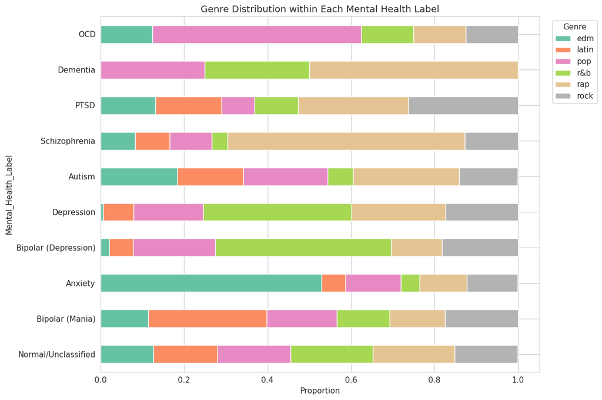

```
=== 라벨별 장르 비율 (%) ===
```

| playlist_genre Mental_Health_Label | edm | latin | pop | r&b | rap | rock |
| --- | --- | --- | --- | --- | --- | --- |
| Normal/Unclassified | 12.7 | 15.3 | 17.5 | 19.7 | 19.6 | 15.1 |
| Bipolar (Mania) | 11.5 | 28.3 | 16.8 | 12.7 | 13.2 | 17.5 |
| Anxiety | 53.0 | 5.7 | 13.2 | 4.5 | 11.4 | 12.1 |
| Bipolar (Depression) | 2.1 | 5.7 | 19.7 | 42.1 | 12.2 | 18.2 |
| Depression | 0.7 | 7.2 | 16.7 | 35.5 | 22.5 | 17.4 |
| Autism | 18.4 | 15.8 | 20.2 | 6.1 | 25.4 | 14.0 |
| Schizophrenia | 8.3 | 8.3 | 10.1 | 3.7 | 56.9 | 12.8 |
| PTSD | 13.2 | 15.8 | 7.9 | 10.5 | 26.3 | 26.3 |
| Dementia | 0.0 | 0.0 | 25.0 | 25.0 | 50.0 | 0.0 |
| OCD | 12.5 | 0.0 | 50.0 | 12.5 | 12.5 | 12.5 |

```python
# 크로스탭: 라벨 × 장르 (비율)
ct = pd.crosstab(df['Mental_Health_Label'], df['playlist_genre'], normalize='index').round(3)
ct = ct.loc[mh_counts.index]  # 곡 수 순서로 정렬

fig, ax = plt.subplots(figsize=(12, 8))
ct.plot(kind='barh', stacked=True, ax=ax, colormap='Set2')
ax.set_xlabel('Proportion')
ax.set_title('Genre Distribution within Each Mental Health Label')
ax.legend(title='Genre', bbox_to_anchor=(1.02, 1), loc='upper left')
plt.tight_layout()
plt.show()

print("=== 라벨별 장르 비율 (%) ===")
(ct * 100).round(1)
```